# Project: Investigate a Dataset - [ TMDb Movie Data ]

- Introduction
- Data Wrangling
- Exploratory Data Analysis
- Conclusions

## Introduction

### Dataset Description

The dataset I have picked for this project is the 'TMDb Movie data' dataset. It is originally sourced from Kaggle and some of the original columns have been dropped. This dataset can be used in identifying what makes a film successful. It contains the following columns:

- id
- imdb_id
- popularity
- budget
- revenue
- original_title
- cast
- homepage
- director
- tagline
- keywords
- overview
- runtime
- genres
- production_companies
- release_date
- vote_count
- vote_average
- release_year
- budget_adj
- revenue_adj

### Question(s) for Analysis

1. Which genres are most popular from year to year?
2. What kinds of properties are associated with movies that have high revenues?
3. Average Runtime Of Movies From Year To Year?
4. Which year had the most number of movies released?
5. Who is the most frequent actor?

```python
#import the needed packages into the notebook
import pandas as pd
import numpy as np
import matplotlib.pyplot as plt
% matplotlib inline
import seaborn as sns
```

### Loading of Packages

The packages pandas, matplotlib, NumPy, Seaborn and matplotlib are imported into the notebook. Pandas and NumPy are for scientific computations while matplotlib and Seaborn are used for data visualizations.

```python
# Upgrade pandas to use dataframe.explode() function.
!pip install --upgrade pandas==0.25.0
```

## Data Wrangling

> **Tip**: In this section of the report, you will load in the data, check for cleanliness, and then trim and clean your dataset for analysis. Make sure that you **document your data cleaning steps in mark-down cells precisely and justify your cleaning decisions.**

### General Properties

> **Tip**: You should *not* perform too many operations in each cell. Create cells freely to explore your data. One option that you can take with this project is to do a lot of explorations in an initial notebook. These don't have to be organized, but make sure you use enough comments to understand the purpose of each code cell. Then, after you're done with your analysis, create a duplicate notebook where you will trim the excess and organize your steps so that you have a flowing, cohesive report.

```python
#Load the data into the dataframe and print the first two rows of the dataset
df = pd.read_csv('tmdb_movies.csv')
df.head()
```

|  | id | imdb_id | popularity | budget | revenue | original_title | cast | homepage | director | tagline | ... | overview | runtime | genres | production_companies | release_date | vote_count | vote_average | release_year | budget_adj | revenue_adj |
| --- | --- | --- | --- | --- | --- | --- | --- | --- | --- | --- | --- | --- | --- | --- | --- | --- | --- | --- | --- | --- | --- |
| 0 | 135397 | tt0369610 | 32.985763 | 150000000 | 1513528810 | Jurassic World | Chris Pratt\|Bryce Dallas Howard\|Irrfan Khan\|Vi... | http://www.jurassicworld.com/ | Colin Trevorrow | The park is open. | ... | Twenty-two years after the events of Jurassic ... | 124 | Action\|Adventure\|Science Fiction\|Thriller | Universal Studios\|Amblin Entertainment\|Legenda... | 6/9/15 | 5562 | 6.5 | 2015 | 1.379999e+08 | 1.392446e+09 |
| 1 | 76341 | tt1392190 | 28.419936 | 150000000 | 378436354 | Mad Max: Fury Road | Tom Hardy\|Charlize Theron\|Hugh Keays-Byrne\|Nic... | http://www.madmaxmovie.com/ | George Miller | What a Lovely Day. | ... | An apocalyptic story set in the furthest reach... | 120 | Action\|Adventure\|Science Fiction\|Thriller | Village Roadshow Pictures\|Kennedy Miller Produ... | 5/13/15 | 6185 | 7.1 | 2015 | 1.379999e+08 | 3.481613e+08 |
| 2 | 262500 | tt2908446 | 13.112507 | 110000000 | 295238201 | Insurgent | Shailene Woodley\|Theo James\|Kate Winslet\|Ansel... | http://www.thedivergentseries.movie/#insurgent | Robert Schwentke | One Choice Can Destroy You | ... | Beatrice Prior must confront her inner demons ... | 119 | Adventure\|Science Fiction\|Thriller | Summit Entertainment\|Mandeville Films\|Red Wago... | 3/18/15 | 2480 | 6.3 | 2015 | 1.012000e+08 | 2.716190e+08 |
| 3 | 140607 | tt2488496 | 11.173104 | 200000000 | 2068178225 | Star Wars: The Force Awakens | Harrison Ford\|Mark Hamill\|Carrie Fisher\|Adam D... | http://www.starwars.com/films/star-wars-episod... | J.J. Abrams | Every generation has a story. | ... | Thirty years after defeating the Galactic Empi... | 136 | Action\|Adventure\|Science Fiction\|Fantasy | Lucasfilm\|Truenorth Productions\|Bad Robot | 12/15/15 | 5292 | 7.5 | 2015 | 1.839999e+08 | 1.902723e+09 |
| 4 | 168259 | tt2820852 | 9.335014 | 190000000 | 1506249360 | Furious 7 | Vin Diesel\|Paul Walker\|Jason Statham\|Michelle ... | http://www.furious7.com/ | James Wan | Vengeance Hits Home | ... | Deckard Shaw seeks revenge against Dominic Tor... | 137 | Action\|Crime\|Thriller | Universal Pictures\|Original Film\|Media Rights ... | 4/1/15 | 2947 | 7.3 | 2015 | 1.747999e+08 | 1.385749e+09 |

5 rows × 21 columns

```python
#print the last two rows of he dataset
df.tail(2)
```

|  | id | imdb_id | popularity | budget | revenue | original_title | cast | homepage | director | tagline | ... | overview | runtime | genres | production_companies | release_date | vote_count | vote_average | release_year | budget_adj | revenue_adj |
| --- | --- | --- | --- | --- | --- | --- | --- | --- | --- | --- | --- | --- | --- | --- | --- | --- | --- | --- | --- | --- | --- |
| 10864 | 21449 | tt0061177 | 0.064317 | 0 | 0 | What's Up, Tiger Lily? | Tatsuya Mihashi\|Akiko Wakabayashi\|Mie Hama\|Joh... | NaN | Woody Allen | WOODY ALLEN STRIKES BACK! | ... | In comic Woody Allen's film debut, he took the... | 80 | Action\|Comedy | Benedict Pictures Corp. | 11/2/66 | 22 | 5.4 | 1966 | 0.000000 | 0.0 |
| 10865 | 22293 | tt0060666 | 0.035919 | 19000 | 0 | Manos: The Hands of Fate | Harold P. Warren\|Tom Neyman\|John Reynolds\|Dian... | NaN | Harold P. Warren | It's Shocking! It's Beyond Your Imagination! | ... | A family gets lost on the road and stumbles up... | 74 | Horror | Norm-Iris | 11/15/66 | 15 | 1.5 | 1966 | 127642.279154 | 0.0 |

2 rows × 21 columns

#### Gathering_Data

The .csv file has been loaded into the dataframe and can now be used and manipulated within the notebook.  
We can also see that there are a number of movies that have a budget and/or revenue of **0** according to the dataset

```python
df.shape
```

```
(10866, 21)
```

#### Dimensions of the dataset

In the above code cell, we are able to identify the number of samples and columns present in the data set. There are **10866** samples and **21** features.

```python
#Check columns with missing values and column datatypes
df.info()
```

```
<class 'pandas.core.frame.DataFrame'>
RangeIndex: 10866 entries, 0 to 10865
Data columns (total 21 columns):
id                      10866 non-null int64
imdb_id                 10856 non-null object
popularity              10866 non-null float64
budget                  10866 non-null int64
revenue                 10866 non-null int64
original_title          10866 non-null object
cast                    10790 non-null object
homepage                2936 non-null object
director                10822 non-null object
tagline                 8042 non-null object
keywords                9373 non-null object
overview                10862 non-null object
runtime                 10866 non-null int64
genres                  10843 non-null object
production_companies    9836 non-null object
release_date            10866 non-null object
vote_count              10866 non-null int64
vote_average            10866 non-null float64
release_year            10866 non-null int64
budget_adj              10866 non-null float64
revenue_adj             10866 non-null float64
dtypes: float64(4), int64(6), object(11)
memory usage: 1.7+ MB
```

#### Dataframe summary

The datatypes of the features present include:

- float
- int
- string(object)

There are also 9 columns that have null values. The columns include:

```python
# Check for the number of unique values in each column
df.nunique()
```

```
id                      10865
imdb_id                 10855
popularity              10814
budget                    557
revenue                  4702
original_title          10571
cast                    10719
homepage                 2896
director                 5067
tagline                  7997
keywords                 8804
overview                10847
runtime                   247
genres                   2039
production_companies     7445
release_date             5909
vote_count               1289
vote_average               72
release_year               56
budget_adj               2614
revenue_adj              4840
dtype: int64
```

#### No. of Unique Values

The number of unique values in each column has been identified

### Data Cleaning

> **Tip**: Make sure that you keep your reader informed on the steps that you are taking in your investigation. Follow every code cell, or every set of related code cells, with a markdown cell to describe to the reader what was found in the preceding cell(s). Try to make it so that the reader can then understand what they will be seeing in the following cell(s).

```python
#drop entries with missing values ()
df.dropna(inplace = True)
df.reset_index(inplace=True, drop=True)
df.head()
```

|  | id | imdb_id | popularity | budget | revenue | original_title | cast | homepage | director | tagline | ... | overview | runtime | genres | production_companies | release_date | vote_count | vote_average | release_year | budget_adj | revenue_adj |
| --- | --- | --- | --- | --- | --- | --- | --- | --- | --- | --- | --- | --- | --- | --- | --- | --- | --- | --- | --- | --- | --- |
| 0 | 135397 | tt0369610 | 32.985763 | 150000000 | 1513528810 | Jurassic World | Chris Pratt\|Bryce Dallas Howard\|Irrfan Khan\|Vi... | http://www.jurassicworld.com/ | Colin Trevorrow | The park is open. | ... | Twenty-two years after the events of Jurassic ... | 124 | Action\|Adventure\|Science Fiction\|Thriller | Universal Studios\|Amblin Entertainment\|Legenda... | 6/9/15 | 5562 | 6.5 | 2015 | 1.379999e+08 | 1.392446e+09 |
| 1 | 76341 | tt1392190 | 28.419936 | 150000000 | 378436354 | Mad Max: Fury Road | Tom Hardy\|Charlize Theron\|Hugh Keays-Byrne\|Nic... | http://www.madmaxmovie.com/ | George Miller | What a Lovely Day. | ... | An apocalyptic story set in the furthest reach... | 120 | Action\|Adventure\|Science Fiction\|Thriller | Village Roadshow Pictures\|Kennedy Miller Produ... | 5/13/15 | 6185 | 7.1 | 2015 | 1.379999e+08 | 3.481613e+08 |
| 2 | 262500 | tt2908446 | 13.112507 | 110000000 | 295238201 | Insurgent | Shailene Woodley\|Theo James\|Kate Winslet\|Ansel... | http://www.thedivergentseries.movie/#insurgent | Robert Schwentke | One Choice Can Destroy You | ... | Beatrice Prior must confront her inner demons ... | 119 | Adventure\|Science Fiction\|Thriller | Summit Entertainment\|Mandeville Films\|Red Wago... | 3/18/15 | 2480 | 6.3 | 2015 | 1.012000e+08 | 2.716190e+08 |
| 3 | 140607 | tt2488496 | 11.173104 | 200000000 | 2068178225 | Star Wars: The Force Awakens | Harrison Ford\|Mark Hamill\|Carrie Fisher\|Adam D... | http://www.starwars.com/films/star-wars-episod... | J.J. Abrams | Every generation has a story. | ... | Thirty years after defeating the Galactic Empi... | 136 | Action\|Adventure\|Science Fiction\|Fantasy | Lucasfilm\|Truenorth Productions\|Bad Robot | 12/15/15 | 5292 | 7.5 | 2015 | 1.839999e+08 | 1.902723e+09 |
| 4 | 168259 | tt2820852 | 9.335014 | 190000000 | 1506249360 | Furious 7 | Vin Diesel\|Paul Walker\|Jason Statham\|Michelle ... | http://www.furious7.com/ | James Wan | Vengeance Hits Home | ... | Deckard Shaw seeks revenge against Dominic Tor... | 137 | Action\|Crime\|Thriller | Universal Pictures\|Original Film\|Media Rights ... | 4/1/15 | 2947 | 7.3 | 2015 | 1.747999e+08 | 1.385749e+09 |

5 rows × 21 columns

Since the columns containing null values are of the string data type, they cannot be filled by the mean of all its values. Therefore, those entries containing null values are dropped.

```python
df.isnull().sum().all()
```

```
False
```

Confirmed that there are no missing values in the dataset.

```python
#Check for duplicates
sum(df.duplicated())
```

```
0
```

There are no duplicated entries in the dataset

```python
df.head()
```

|  | id | imdb_id | popularity | budget | revenue | original_title | cast | homepage | director | tagline | ... | overview | runtime | genres | production_companies | release_date | vote_count | vote_average | release_year | budget_adj | revenue_adj |
| --- | --- | --- | --- | --- | --- | --- | --- | --- | --- | --- | --- | --- | --- | --- | --- | --- | --- | --- | --- | --- | --- |
| 0 | 135397 | tt0369610 | 32.985763 | 150000000 | 1513528810 | Jurassic World | Chris Pratt\|Bryce Dallas Howard\|Irrfan Khan\|Vi... | http://www.jurassicworld.com/ | Colin Trevorrow | The park is open. | ... | Twenty-two years after the events of Jurassic ... | 124 | Action\|Adventure\|Science Fiction\|Thriller | Universal Studios\|Amblin Entertainment\|Legenda... | 6/9/15 | 5562 | 6.5 | 2015 | 1.379999e+08 | 1.392446e+09 |
| 1 | 76341 | tt1392190 | 28.419936 | 150000000 | 378436354 | Mad Max: Fury Road | Tom Hardy\|Charlize Theron\|Hugh Keays-Byrne\|Nic... | http://www.madmaxmovie.com/ | George Miller | What a Lovely Day. | ... | An apocalyptic story set in the furthest reach... | 120 | Action\|Adventure\|Science Fiction\|Thriller | Village Roadshow Pictures\|Kennedy Miller Produ... | 5/13/15 | 6185 | 7.1 | 2015 | 1.379999e+08 | 3.481613e+08 |
| 2 | 262500 | tt2908446 | 13.112507 | 110000000 | 295238201 | Insurgent | Shailene Woodley\|Theo James\|Kate Winslet\|Ansel... | http://www.thedivergentseries.movie/#insurgent | Robert Schwentke | One Choice Can Destroy You | ... | Beatrice Prior must confront her inner demons ... | 119 | Adventure\|Science Fiction\|Thriller | Summit Entertainment\|Mandeville Films\|Red Wago... | 3/18/15 | 2480 | 6.3 | 2015 | 1.012000e+08 | 2.716190e+08 |
| 3 | 140607 | tt2488496 | 11.173104 | 200000000 | 2068178225 | Star Wars: The Force Awakens | Harrison Ford\|Mark Hamill\|Carrie Fisher\|Adam D... | http://www.starwars.com/films/star-wars-episod... | J.J. Abrams | Every generation has a story. | ... | Thirty years after defeating the Galactic Empi... | 136 | Action\|Adventure\|Science Fiction\|Fantasy | Lucasfilm\|Truenorth Productions\|Bad Robot | 12/15/15 | 5292 | 7.5 | 2015 | 1.839999e+08 | 1.902723e+09 |
| 4 | 168259 | tt2820852 | 9.335014 | 190000000 | 1506249360 | Furious 7 | Vin Diesel\|Paul Walker\|Jason Statham\|Michelle ... | http://www.furious7.com/ | James Wan | Vengeance Hits Home | ... | Deckard Shaw seeks revenge against Dominic Tor... | 137 | Action\|Crime\|Thriller | Universal Pictures\|Original Film\|Media Rights ... | 4/1/15 | 2947 | 7.3 | 2015 | 1.747999e+08 | 1.385749e+09 |

5 rows × 21 columns

The column genre contains multiple values in as one value separated by '|'.

```python
#separate the values in genres column
df['genres'] = df.genres.str.split('|')
df = df.explode('genres').reset_index(drop=True)
```

```python
df.head(2)
```

|  | id | imdb_id | popularity | budget | revenue | original_title | cast | homepage | director | tagline | ... | overview | runtime | genres | production_companies | release_date | vote_count | vote_average | release_year | budget_adj | revenue_adj |
| --- | --- | --- | --- | --- | --- | --- | --- | --- | --- | --- | --- | --- | --- | --- | --- | --- | --- | --- | --- | --- | --- |
| 0 | 135397 | tt0369610 | 32.985763 | 150000000 | 1513528810 | Jurassic World | Chris Pratt\|Bryce Dallas Howard\|Irrfan Khan\|Vi... | http://www.jurassicworld.com/ | Colin Trevorrow | The park is open. | ... | Twenty-two years after the events of Jurassic ... | 124 | Action | Universal Studios\|Amblin Entertainment\|Legenda... | 6/9/15 | 5562 | 6.5 | 2015 | 1.379999e+08 | 1.392446e+09 |
| 1 | 135397 | tt0369610 | 32.985763 | 150000000 | 1513528810 | Jurassic World | Chris Pratt\|Bryce Dallas Howard\|Irrfan Khan\|Vi... | http://www.jurassicworld.com/ | Colin Trevorrow | The park is open. | ... | Twenty-two years after the events of Jurassic ... | 124 | Adventure | Universal Studios\|Amblin Entertainment\|Legenda... | 6/9/15 | 5562 | 6.5 | 2015 | 1.379999e+08 | 1.392446e+09 |

2 rows × 21 columns

```python
df.info()
```

```
<class 'pandas.core.frame.DataFrame'>
RangeIndex: 5123 entries, 0 to 5122
Data columns (total 21 columns):
id                      5123 non-null int64
imdb_id                 5123 non-null object
popularity              5123 non-null float64
budget                  5123 non-null int64
revenue                 5123 non-null int64
original_title          5123 non-null object
cast                    5123 non-null object
homepage                5123 non-null object
director                5123 non-null object
tagline                 5123 non-null object
keywords                5123 non-null object
overview                5123 non-null object
runtime                 5123 non-null int64
genres                  5123 non-null object
production_companies    5123 non-null object
release_date            5123 non-null object
vote_count              5123 non-null int64
vote_average            5123 non-null float64
release_year            5123 non-null int64
budget_adj              5123 non-null float64
revenue_adj             5123 non-null float64
dtypes: float64(4), int64(6), object(11)
memory usage: 840.6+ KB
```

The values in the genres column have been separated and added as unique rows

```python
df.genres.unique()
```

```
array(['Action', 'Adventure', 'Science Fiction', 'Thriller', 'Fantasy',
       'Crime', 'Western', 'Drama', 'Family', 'Animation', 'Comedy',
       'Mystery', 'War', 'Romance', 'History', 'Horror', 'Music',
       'Documentary', 'TV Movie', 'Foreign'], dtype=object)
```

```python
#Convert the datatype of release_date from string to date format
df['release_date'] = pd.to_datetime(df['release_date']).dt.date
df['release_date'].head()
```

```
0    2015-06-09
1    2015-06-09
2    2015-06-09
3    2015-06-09
4    2015-05-13
Name: release_date, dtype: object
```

```python
#Drop unecessary columns
df.drop(['imdb_id', 'tagline', 'overview', 'homepage', 'budget_adj', 'revenue_adj'], axis=1, inplace=True)
```

```python
df.columns
```

```
Index(['id', 'popularity', 'budget', 'revenue', 'original_title', 'cast',
       'director', 'keywords', 'runtime', 'genres', 'production_companies',
       'release_date', 'vote_count', 'vote_average', 'release_year'],
      dtype='object')
```

Columns that contained unnecessary data to be used for the analysis are dropped. This includes;

- imdb_id
- tagline
- overview
- homepage
- budget_adj
- revenue_adj

```python
#Drop rows with incorrect values
df = df[df.budget != 0]
df = df[df.revenue != 0]
```

The rows that conatine a value of zero in the budget and/or revenue columns have been dropped.

```python
#Check if there is a value in the budget column that contains zero
df.query('budget == 0').sum().all()
```

```
False
```

```python
#Check if there is a value in the revenue column that contains zero
df.query('revenue == 0').sum().all()
```

```
False
```

## Exploratory Data Analysis

> **Tip**: Now that you've trimmed and cleaned your data, you're ready to move on to exploration. **Compute statistics** and **create visualizations** with the goal of addressing the research questions that you posed in the Introduction section. You should compute the relevant statistics throughout the analysis when an inference is made about the data. Note that at least two or more kinds of plots should be created as part of the exploration, and you must compare and show trends in the varied visualizations.

> **Tip**: - Investigate the stated question(s) from multiple angles. It is recommended that you be systematic with your approach. Look at one variable at a time, and then follow it up by looking at relationships between variables. You should explore at least three variables in relation to the primary question. This can be an exploratory relationship between three variables of interest, or looking at how two independent variables relate to a single dependent variable of interest. Lastly, you should perform both single-variable (1d) and multiple-variable (2d) explorations.

### Which genres are most popular from year to year?

```python
# Use this, and more code cells, to explore your data. Don't forget to add
#   Markdown cells to document your observations and findings.

popular_genre = df.groupby(['release_year'], as_index=False)['popularity', 'genres'].max()
popular_genre
```

|  | release_year | popularity | genres |
| --- | --- | --- | --- |
| 0 | 1961 | 0.303783 | Family |
| 1 | 1962 | 3.170651 | Thriller |
| 2 | 1963 | 2.508235 | Thriller |
| 3 | 1964 | 3.153791 | Thriller |
| 4 | 1965 | 1.910465 | Thriller |
| 5 | 1967 | 1.554808 | Thriller |
| 6 | 1969 | 1.778746 | Thriller |
| 7 | 1971 | 1.755117 | Thriller |
| 8 | 1972 | 5.738034 | Drama |
| 9 | 1973 | 2.010733 | Thriller |
| 10 | 1974 | 1.619555 | Thriller |
| 11 | 1975 | 2.563191 | Thriller |
| 12 | 1977 | 12.037933 | Thriller |
| 13 | 1978 | 1.198849 | Thriller |
| 14 | 1979 | 4.935897 | War |
| 15 | 1980 | 5.488441 | Science Fiction |
| 16 | 1981 | 4.578300 | Thriller |
| 17 | 1982 | 4.215642 | Thriller |
| 18 | 1983 | 4.828854 | Thriller |
| 19 | 1984 | 4.831966 | Thriller |
| 20 | 1985 | 6.095293 | Thriller |
| 21 | 1986 | 0.960984 | Fantasy |
| 22 | 1987 | 1.945847 | Thriller |
| 23 | 1988 | 0.540362 | Thriller |
| 24 | 1989 | 3.536655 | Thriller |
| 25 | 1990 | 2.441201 | Thriller |
| 26 | 1991 | 3.852269 | Thriller |
| 27 | 1992 | 3.966538 | Thriller |
| 28 | 1993 | 2.377288 | War |
| 29 | 1994 | 4.782688 | Romance |
| 30 | 1995 | 4.765359 | Thriller |
| 31 | 1996 | 3.293387 | Thriller |
| 32 | 1997 | 4.355219 | Thriller |
| 33 | 1998 | 2.729745 | War |
| 34 | 1999 | 8.947905 | Thriller |
| 35 | 2000 | 3.095625 | War |
| 36 | 2001 | 8.575419 | Thriller |
| 37 | 2002 | 8.095275 | War |
| 38 | 2003 | 7.122455 | Thriller |
| 39 | 2004 | 3.863377 | Western |
| 40 | 2005 | 5.939927 | Western |
| 41 | 2006 | 5.838503 | War |
| 42 | 2007 | 4.965391 | Western |
| 43 | 2008 | 8.466668 | War |
| 44 | 2009 | 9.432768 | War |
| 45 | 2010 | 9.363643 | Western |
| 46 | 2011 | 7.959228 | Western |
| 47 | 2012 | 7.637767 | Western |
| 48 | 2013 | 6.112766 | Western |
| 49 | 2014 | 24.949134 | War |
| 50 | 2015 | 32.985763 | Western |

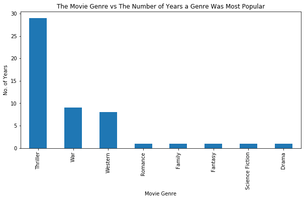

```python
popular_genre['genres'].value_counts().plot(kind='bar', figsize=(10,5))
plt.title('The Movie Genre vs The Number of Years a Genre Was Most Popular')
plt.xlabel('Movie Genre')
plt.ylabel('No. of Years');
```

### What kinds of properties are associated with movies that have high revenues?

```python
df.describe()
```

|  | id | popularity | budget | revenue | runtime | vote_count | vote_average | release_year |
| --- | --- | --- | --- | --- | --- | --- | --- | --- |
| count | 3454.000000 | 3454.000000 | 3.454000e+03 | 3.454000e+03 | 3454.000000 | 3454.000000 | 3454.000000 | 3454.000000 |
| mean | 50562.479444 | 1.943818 | 5.896150e+07 | 1.986301e+08 | 110.530400 | 1051.530979 | 6.275680 | 2006.825420 |
| std | 71600.489497 | 2.390084 | 5.878653e+07 | 2.750308e+08 | 19.170809 | 1342.024724 | 0.794252 | 8.296974 |
| min | 11.000000 | 0.010335 | 1.000000e+00 | 4.300000e+01 | 63.000000 | 10.000000 | 2.200000 | 1961.000000 |
| 25% | 5137.000000 | 0.723825 | 1.500000e+07 | 2.900000e+07 | 97.000000 | 205.000000 | 5.800000 | 2005.000000 |
| 50% | 18947.000000 | 1.246595 | 4.000000e+07 | 9.520220e+07 | 107.000000 | 509.500000 | 6.300000 | 2009.000000 |
| 75% | 60935.000000 | 2.391809 | 8.000000e+07 | 2.504381e+08 | 121.000000 | 1373.000000 | 6.800000 | 2011.000000 |
| max | 333348.000000 | 32.985763 | 4.250000e+08 | 2.781506e+09 | 201.000000 | 9767.000000 | 8.300000 | 2015.000000 |

The properties that associate with high revenue of movies include:

- popularity
- budget
- runtime
- vote_count
- vote_average
- release_year

We will use all these features except release_year and vote_count to evaluate the relationship with revenue

```python
#Create a function that plots a scatter plot
def plot(x, y):
    plt.subplots(figsize=(10,5))
    plt.scatter(df[x], df[y])
    plt.title('{x} vs {y}'.format(x=x, y=y), fontsize=16)
    plt.xlabel(x, fontsize=13)
    plt.ylabel(y, fontsize=13)

plt.show()
```

The function **plot()** creates scatter plots. It'll be used to display the relationship between revenue and other features.

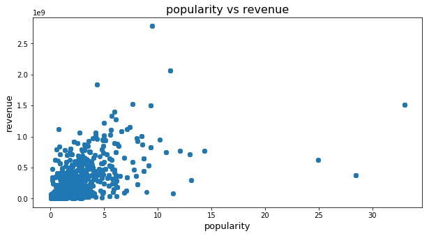

```python
#Plot the relationship between Popularity and Revenue
plot('popularity', 'revenue')
```

```python
df['revenue'].corr(df['popularity'])
```

```
0.5876540607813082
```

There is a positive correlation between Popularity and Revenue.It is highly related because an increase in popularity results to an increase in revenue.

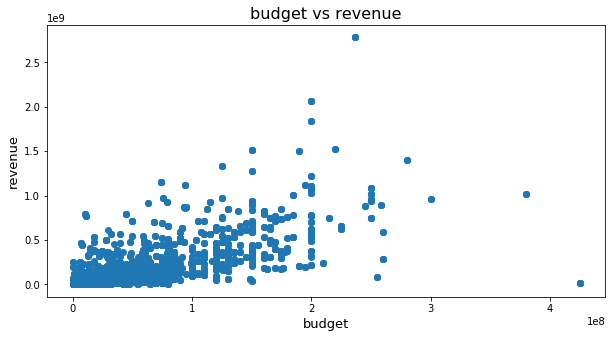

```python
#Plot the relationship between Budget and Revenue
plot('budget', 'revenue')
```

```python
df['revenue'].corr(df['budget'])
```

```
0.6861955671166574
```

There is a postive correlation between the budget and the revenue.It is highly related because an increase in budget results to an increase in revenue

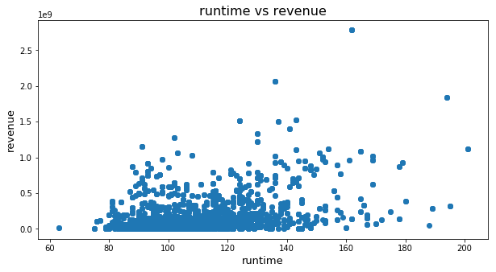

```python
#Plot the relationship between runtime and revenue
plot('runtime', 'revenue')
```

```python
df['revenue'].corr(df['runtime'])
```

```
0.36158234115224136
```

There is a positive correlation between the Runtime and the Revenue, but it is not highly related.

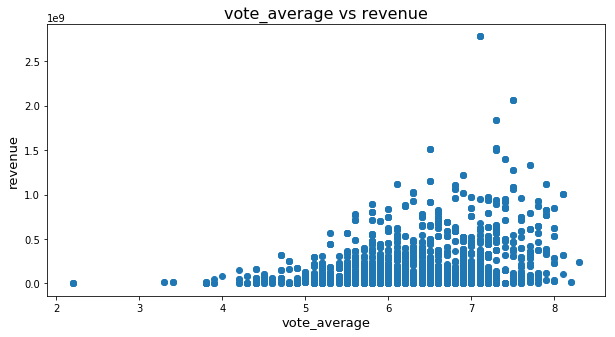

```python
#Plot the relationship between Vote Average and revenue
plot('vote_average', 'revenue')
```

```python
df['revenue'].corr(df['vote_average'])
```

```
0.32402391813226034
```

There is a positive correlation between Vote Average and Revenue, but not highly related.

### What is the average Runtime Of Movies From Year To Year?

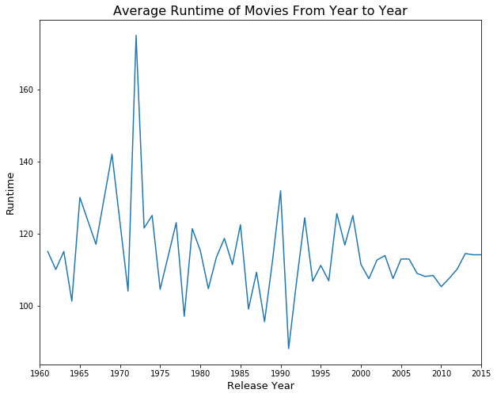

```python
#Find the average runtime each year
average_time = df.groupby('release_year')['runtime'].mean()
average_time.plot(xticks = np.arange(1960, 2016, 5), figsize=(10,8))
plt.title('Average Runtime of Movies From Year to Year', fontsize=16)
plt.xlabel('Release Year', fontsize=13)
plt.ylabel('Runtime', fontsize=13);
```

### Which year had the most number of movies released?

```python
#Find the total number of movies released each year
total_movies = df.groupby('release_year')['id'].count()
total_movies.tail(6)
```

```
release_year
2010    348
2011    398
2012    238
2013    184
2014    182
2015    252
Name: id, dtype: int64
```

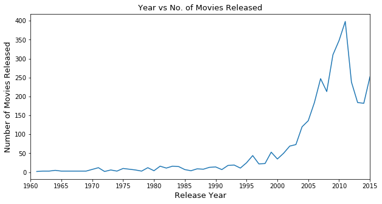

```python
#Plot a graph to display the results
total_movies.plot(xticks = np.arange(1960, 2020, 5), figsize=(10,5));
plt.title("Year vs No. of Movies Released", fontsize=13)
plt.xlabel("Release Year", fontsize=13)
plt.ylabel("Number of Movies Released", fontsize=13);
```

### Who is the most frequent actor?

```python
#separate the values in cast column
df.cast = df.cast.str.split('|')
df = df.explode('cast').reset_index(drop=True)
df.head(3)
```

|  | id | popularity | budget | revenue | original_title | cast | director | keywords | runtime | genres | production_companies | release_date | vote_count | vote_average | release_year |
| --- | --- | --- | --- | --- | --- | --- | --- | --- | --- | --- | --- | --- | --- | --- | --- |
| 0 | 135397 | 32.985763 | 150000000 | 1513528810 | Jurassic World | Chris Pratt | Colin Trevorrow | monster\|dna\|tyrannosaurus rex\|velociraptor\|island | 124 | Action | Universal Studios\|Amblin Entertainment\|Legenda... | 2015-06-09 | 5562 | 6.5 | 2015 |
| 1 | 135397 | 32.985763 | 150000000 | 1513528810 | Jurassic World | Bryce Dallas Howard | Colin Trevorrow | monster\|dna\|tyrannosaurus rex\|velociraptor\|island | 124 | Action | Universal Studios\|Amblin Entertainment\|Legenda... | 2015-06-09 | 5562 | 6.5 | 2015 |
| 2 | 135397 | 32.985763 | 150000000 | 1513528810 | Jurassic World | Irrfan Khan | Colin Trevorrow | monster\|dna\|tyrannosaurus rex\|velociraptor\|island | 124 | Action | Universal Studios\|Amblin Entertainment\|Legenda... | 2015-06-09 | 5562 | 6.5 | 2015 |

The values in the cast column separated by "|" have been split and df.explode() used to place them in individual rows.

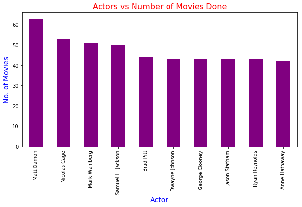

```python
#Plot a bar graph to show the most frequent actor over the years
df['cast'].value_counts().iloc[:10].plot(kind='bar', color="purple", figsize=(10,5))
plt.title("Actors vs Number of Movies Done", color='red', fontsize=16)
plt.xlabel('Actor', fontsize=14, color="blue")
plt.ylabel('No. of Movies', fontsize=14, color='blue');
```

```python
df.query('cast == "Matt Damon"')['id'].count()
```

```
63
```

## Conclusions

### Limitations

1. There were very many missing values that affect the accuracy of the analysis
2. The columns budget and revenue had many zeros which resulted in those entries being dropped from the analysis.

## Submitting your Project

> **Tip**: Before you submit your project, you need to create a .html or .pdf version of this notebook in the workspace here. To do that, run the code cell below. If it worked correctly, you should get a return code of 0, and you should see the generated .html file in the workspace directory (click on the orange Jupyter icon in the upper left).

> **Tip**: Alternatively, you can download this report as .html via the **File** > **Download as** submenu, and then manually upload it into the workspace directory by clicking on the orange Jupyter icon in the upper left, then using the Upload button.

> **Tip**: Once you've done this, you can submit your project by clicking on the "Submit Project" button in the lower right here. This will create and submit a zip file with this .ipynb doc and the .html or .pdf version you created. Congratulations!

```python
from subprocess import call
call(['python', '-m', 'nbconvert', 'Investigate_a_Dataset.ipynb'])
```

```
0
```